# p03-desarrollar-datos

```python
import pandas as pd
import numpy as np
import matplotlib.pyplot as plt
plt.rcParams['figure.figsize'] = (12,12)
```

### Generando funciones de apoyo a los resultados

```python
data_file="../data/intermediate/netflix-categorizado.pkl"
data_origen = pd.read_pickle(data_file)
```

```python
def cargar_dataset(nombre_archivo, nombre_columna):
    df = pd.read_csv(nombre_archivo)
    df.columns=["id", nombre_columna]
    return df
```

```python
%matplotlib inline
def graficar(titulo, xlabel, ylabel):
    plt.title(titulo)
    plt.xlabel(xlabel)
    plt.ylabel(ylabel)
    plt.show()
```

```python
def combinar_dataframe(df_left, df_right):
    df_merged = pd.merge(
        left=df_left, right=df_right,
        left_on='id', right_on='id')
    return df_merged
```

# Pregunta 1: Comprender qué contenido está disponible en diferentes países

```python
data_paises =cargar_dataset("../data/intermediate/netflix-paises.csv", "pais")
paises_merged=combinar_dataframe(data_paises, data_origen)
```

```python
copia = paises_merged.copy()
df =copia[["id", "publico"]]
df["cantidad"]=0
contenido = df["publico"].value_counts().to_frame()
contenido.reindex()
contenido["porcentaje"]=round(((contenido["publico"]/len(paises_merged))*100),1)
```

## Tipos de contenidos brindados por Netflix

Netflix posee un amplio catálogo que diferencia el tipo de contenido a diferente publico, con la muestra obtenida se identifican las siguientes clasificaciones de público objetivo:

```python
contenido
```

|  | publico | porcentaje |
| --- | --- | --- |
| Adulto | 3451 | 45.1 |
| Adolecente | 2357 | 30.8 |
| infantil | 1836 | 24.0 |
| Sin clasificar | 10 | 0.1 |

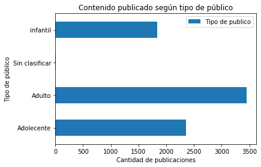

```python
contenido = paises_merged.groupby("publico")["publico"].count().plot(kind="barh", legend="Reverse").legend(["Tipo de publico"])
graficar("Contenido publicado según tipo de público", "Cantidad de publicaciones", "Tipo de público")
```

La gráfica muestra como el contenido para adultos (mayores de 18 años) es el prevalente con un 45.1%. Por otra parte los adolecentes (entre 13 y 18 años) tienen un 30.8% de las publicaciones. El público infantil (menores a 8 años) tambien poseen contenido exclusivo para ellos y representa el 24%. Existen en la muestra items no etiquetados que tan solo son el 0.1% y fueron catalogados como "Sin clasificar".

Para este analisis serán utilizados los paises de America del sur debido a que la muestra en este aspecto es muy extensa.

```python
paises_america =["Argentina", "Brazil", "Bolivia", "Chile", "Colombia", "Ecuador", "Paraguay", "Peru", "Uruguay", "Venezuela"]
df = paises_merged.loc[paises_merged["pais"].isin(paises_america), ["id", "pais", "publico"]]
print("Cantidad de titulos encontrados:", len(df))
contenido= df.pivot_table(index="pais", columns="publico", aggfunc="count", fill_value=0.0, margins=True, margins_name="Total")
contenido.head(10)
```

```
Cantidad de titulos encontrados: 216
```

| publico pais | id Adolecente | id Adulto | id infantil | id Total |
| --- | --- | --- | --- | --- |
| Argentina | 8 | 52 | 8 | 68 |
| Brazil | 11 | 43 | 12 | 66 |
| Chile | 4 | 18 | 1 | 23 |
| Colombia | 14 | 20 | 2 | 36 |
| Ecuador | 0 | 0 | 1 | 1 |
| Paraguay | 0 | 1 | 0 | 1 |
| Peru | 1 | 7 | 1 | 9 |
| Uruguay | 2 | 6 | 1 | 9 |
| Venezuela | 2 | 1 | 0 | 3 |
| Total | 42 | 148 | 26 | 216 |

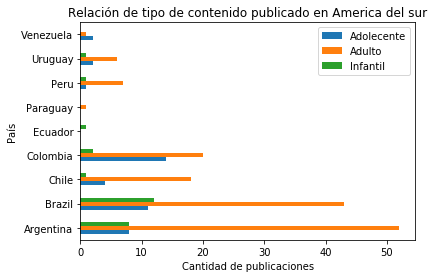

```python
contenido= df.pivot_table(index="pais", columns="publico", aggfunc="count", fill_value=0)
contenido.plot(kind="barh", legend="Reverse").legend(["Adolecente", "Adulto", "Infantil"])
graficar("Relación de tipo de contenido publicado en America del sur", "Cantidad de publicaciones", "País")
```

La gráfica indica que en Argentina, Brasil, Chile y Colombia son los paises con mas contenido disponible, siendo Argentina el país con mas publicaciones para adultos (mayores de 18 años). Sin embargo, Colombia posee la mayoria de publicaciones para adolecentes (entre 13 y 17 años) y en Brasil se publica un contenido para niños (menores a 13 años) superior al resto de los paises.

# Pregunta 2: Identificar contenido similar haciendo coincidir características basadas en países

```python
data_clasificacion =cargar_dataset("../data/intermediate/netflix-clasificacion.csv", "clasificacion")
clasificacion_merged=combinar_dataframe(data_clasificacion, data_origen)
```

```python
copia = clasificacion_merged.copy()
df =copia[["id", "clasificacion"]]
df["cantidad"]=0
contenido = df["clasificacion"].value_counts().to_frame()
contenido.reindex()
contenido["porcentaje"]=round(((contenido["clasificacion"]/len(clasificacion_merged))*100),1)
```

Netflic posee muchas variedades de contenido siendo estas las siguientes:

```python
contenido
```

|  | clasificacion | porcentaje |
| --- | --- | --- |
| International Movies | 1927 | 14.1 |
| Dramas | 1623 | 11.9 |
| Comedies | 1113 | 8.1 |
| International TV Shows | 1001 | 7.3 |
| Documentaries | 668 | 4.9 |
| TV Dramas | 599 | 4.4 |
| Action & Adventure | 597 | 4.4 |
| Independent Movies | 552 | 4.0 |
| TV Comedies | 436 | 3.2 |
| Thrillers | 392 | 2.9 |
| Children & Family Movies | 377 | 2.8 |
| Romantic Movies | 376 | 2.8 |
| Crime TV Shows | 363 | 2.7 |
| Kids' TV | 328 | 2.4 |
| Stand-Up Comedy | 281 | 2.1 |
| Docuseries | 279 | 2.0 |
| Romantic TV Shows | 278 | 2.0 |
| Horror Movies | 262 | 1.9 |
| Music & Musicals | 243 | 1.8 |
| British TV Shows | 210 | 1.5 |
| Sci-Fi & Fantasy | 193 | 1.4 |
| Sports Movies | 157 | 1.1 |
| Reality TV | 153 | 1.1 |
| Korean TV Shows | 132 | 1.0 |
| TV Action & Adventure | 126 | 0.9 |
| Anime Series | 117 | 0.9 |
| Spanish-Language TV Shows | 117 | 0.9 |
| Classic Movies | 84 | 0.6 |
| TV Mysteries | 69 | 0.5 |
| TV Sci-Fi & Fantasy | 68 | 0.5 |
| Science & Nature TV | 67 | 0.5 |
| LGBTQ Movies | 60 | 0.4 |
| Movies | 56 | 0.4 |
| Cult Movies | 55 | 0.4 |
| TV Horror | 54 | 0.4 |
| Faith & Spirituality | 47 | 0.3 |
| Anime Features | 45 | 0.3 |
| TV Thrillers | 44 | 0.3 |
| Teen TV Shows | 44 | 0.3 |
| Stand-Up Comedy & Talk Shows | 42 | 0.3 |
| Classic & Cult TV | 24 | 0.2 |
| TV Shows | 10 | 0.1 |

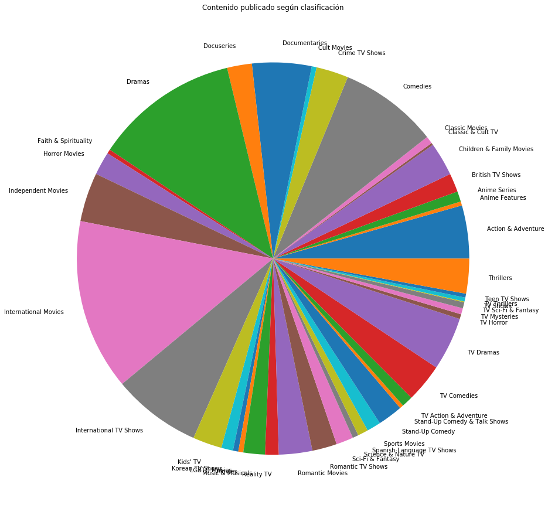

```python
plt.rcParams['figure.figsize'] = (15,25)
clasificacion_merged.clasificacion.groupby(clasificacion_merged.clasificacion).count().plot(kind="pie")
graficar("Contenido publicado según clasificación", "", "")
```

Dentro de todas las clasificaciones encontradas, el mayor porcentaje de publicaciones pertenece a películas internacionales (14.1%), seguida por dramas (11.9%), comedias (8.1%) y shows de televisión internacional (7.3%) A continuación se visualizarán estas cuatro clasificaciones en los principales paises de latinoamerica donde Netflix posee mayor cantidad de publicaciones que segun el punto 2, resultaron ser Argentina, Brasil, Chile y Colombia.

```python
clasificacion_merged = combinar_dataframe(data_clasificacion, data_paises)
paises_america=["Argentina", "Brazil", "Chile", "Colombia"]
clasificaciones=["International Movies", "Dramas", "Comedies", "International TV Shows"]
df = clasificacion_merged.loc[clasificacion_merged["pais"].isin(paises_america), ["id", "pais", "clasificacion"]]
df = df.loc[df["clasificacion"].isin(clasificaciones), ["id", "pais", "clasificacion"]]
df.sort_values(["pais", "clasificacion"], ascending=True, inplace=True)
print("Cantidad de películas encontradas:", len(df))
contenido= df.pivot_table(index="pais", columns="clasificacion", aggfunc="count", fill_value=0, margins=True, margins_name="Total")
contenido.head()
```

```
Cantidad de películas encontradas: 240
```

| clasificacion pais | id Comedies | id Dramas | id International Movies | id International TV Shows | id Total |
| --- | --- | --- | --- | --- | --- |
| Argentina | 10 | 27 | 42 | 10 | 89 |
| Brazil | 11 | 22 | 32 | 14 | 79 |
| Chile | 6 | 9 | 13 | 4 | 32 |
| Colombia | 5 | 4 | 10 | 21 | 40 |
| Total | 32 | 62 | 97 | 49 | 240 |

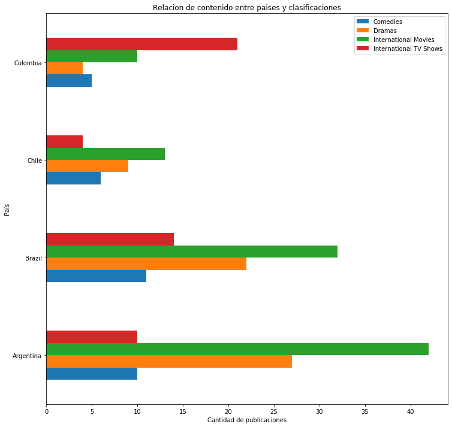

```python
plt.rcParams['figure.figsize'] = (12,12)
contenido= df.pivot_table(index="pais", columns="clasificacion", aggfunc="count", fill_value=0)
contenido.plot(kind="barh", legend="Reverse").legend(["Comedies", "Dramas","International Movies", "International TV Shows"])
graficar("Relacion de contenido entre paises y clasificaciones", "Cantidad de publicaciones", "País")
```

# Pregunta 3: Análisis de la red de actores / directores y encontrar ideas interesantes en base a países y años

## Analisis de directores

```python
data_director =cargar_dataset("../data/intermediate/netflix-directores.csv", "director")
director_merged  = combinar_dataframe(data_director, data_origen)
copia = director_merged.copy()
df =copia[["id", "director", "lanzamiento"]]
contenido = df["director"].value_counts().to_frame()
contenido = contenido[1:11]
```

Los directores con mas películas publicadas en Netflix son:

```python
contenido
```

|  | director |
| --- | --- |
| Jan Suter | 21 |
| Raúl Campos | 19 |
| Marcus Raboy | 14 |
| Jay Karas | 14 |
| Jay Chapman | 12 |
| Steven Spielberg | 9 |
| Martin Scorsese | 9 |
| Lance Bangs | 8 |
| David Dhawan | 8 |
| Johnnie To | 8 |

```python
directores = contenido["director"].to_dict().keys()
copia = director_merged.copy()
df = copia.loc[copia["director"].isin(directores), ["id", "director", "lanzamiento"]]
```

Tabla de relación de año de lanzamiento versus director

```python
contenido = df.pivot_table(index="lanzamiento", columns="director", aggfunc="count", fill_value=0, margins=True)
contenido
```

| director lanzamiento | id David Dhawan | id Jan Suter | id Jay Chapman | id Jay Karas | id Johnnie To | id Lance Bangs | id Marcus Raboy | id Martin Scorsese | id Raúl Campos | id Steven Spielberg | id All |
| --- | --- | --- | --- | --- | --- | --- | --- | --- | --- | --- | --- |
| 1967 | 0 | 0 | 0 | 0 | 0 | 0 | 0 | 1 | 0 | 0 | 1 |
| 1973 | 0 | 0 | 0 | 0 | 0 | 0 | 0 | 1 | 0 | 0 | 1 |
| 1974 | 0 | 0 | 0 | 0 | 0 | 0 | 0 | 1 | 0 | 0 | 1 |
| 1976 | 0 | 0 | 0 | 0 | 0 | 0 | 0 | 1 | 0 | 0 | 1 |
| 1980 | 0 | 0 | 0 | 0 | 0 | 0 | 0 | 1 | 0 | 0 | 1 |
| 1981 | 0 | 0 | 0 | 0 | 0 | 0 | 0 | 0 | 0 | 1 | 1 |
| 1984 | 0 | 0 | 0 | 0 | 0 | 0 | 0 | 0 | 0 | 1 | 1 |
| 1989 | 0 | 0 | 0 | 0 | 0 | 0 | 0 | 0 | 0 | 1 | 1 |
| 1992 | 0 | 0 | 0 | 0 | 1 | 0 | 0 | 0 | 0 | 0 | 1 |
| 1993 | 0 | 0 | 0 | 0 | 1 | 0 | 0 | 0 | 0 | 1 | 2 |
| 1995 | 0 | 0 | 0 | 0 | 1 | 0 | 0 | 0 | 0 | 0 | 1 |
| 1997 | 1 | 0 | 0 | 0 | 1 | 0 | 0 | 0 | 0 | 0 | 2 |
| 1999 | 1 | 0 | 0 | 0 | 0 | 0 | 0 | 0 | 0 | 0 | 1 |
| 2000 | 1 | 0 | 0 | 0 | 0 | 0 | 0 | 0 | 0 | 0 | 1 |
| 2001 | 1 | 0 | 0 | 0 | 0 | 0 | 0 | 0 | 0 | 0 | 1 |
| 2002 | 0 | 0 | 0 | 0 | 0 | 0 | 0 | 1 | 0 | 1 | 2 |
| 2004 | 1 | 0 | 0 | 0 | 0 | 0 | 0 | 0 | 0 | 0 | 1 |
| 2005 | 1 | 0 | 0 | 0 | 0 | 0 | 0 | 0 | 0 | 0 | 1 |
| 2006 | 0 | 0 | 0 | 0 | 0 | 0 | 0 | 1 | 0 | 0 | 1 |
| 2008 | 0 | 0 | 0 | 0 | 0 | 0 | 0 | 0 | 0 | 1 | 1 |
| 2011 | 0 | 0 | 0 | 0 | 1 | 0 | 0 | 0 | 0 | 2 | 3 |
| 2012 | 0 | 0 | 2 | 2 | 0 | 0 | 1 | 0 | 0 | 1 | 6 |
| 2013 | 1 | 0 | 1 | 0 | 1 | 1 | 0 | 0 | 0 | 0 | 4 |
| 2014 | 0 | 0 | 3 | 1 | 1 | 1 | 0 | 0 | 0 | 0 | 6 |
| 2015 | 0 | 0 | 1 | 2 | 0 | 2 | 0 | 0 | 0 | 0 | 5 |
| 2016 | 0 | 4 | 0 | 3 | 1 | 1 | 1 | 0 | 3 | 0 | 13 |
| 2017 | 1 | 5 | 4 | 2 | 0 | 1 | 6 | 0 | 4 | 0 | 23 |
| 2018 | 0 | 12 | 1 | 3 | 0 | 1 | 3 | 0 | 12 | 0 | 32 |
| 2019 | 0 | 0 | 0 | 1 | 0 | 1 | 3 | 2 | 0 | 0 | 7 |
| All | 8 | 21 | 12 | 14 | 8 | 8 | 14 | 9 | 19 | 9 | 122 |

## Analisis de actores

```python
data_actores =cargar_dataset("../data/intermediate/netflix-actores.csv", "actor")
actores_merged  = combinar_dataframe(data_actores, data_origen)
copia = actores_merged.copy()
df =copia[["id", "actor", "lanzamiento"]]
contenido = df["actor"].value_counts().to_frame()
contenido = contenido[1:11]
```

Los actores que han participado en más películas son:

```python
contenido
```

|  | actor |
| --- | --- |
| Anupam Kher | 33 |
| Shah Rukh Khan | 30 |
| Naseeruddin Shah | 27 |
| Om Puri | 27 |
| Akshay Kumar | 26 |
| Yuki Kaji | 26 |
| Paresh Rawal | 25 |
| Takahiro Sakurai | 25 |
| Amitabh Bachchan | 24 |
| Boman Irani | 23 |

```python
actores = contenido["actor"].to_dict().keys()
copia = actores_merged.copy()
df = copia.loc[copia["actor"].isin(actores), ["id", "actor", "publico"]]
print("Titulos encontrados:", len(df))
contenido = df.pivot_table(index="actor", columns="publico", aggfunc="count", fill_value=0, margins=True, margins_name="Total")
contenido
```

```
Titulos encontrados: 266
```

| publico actor | id Adolecente | id Adulto | id infantil | id Total |
| --- | --- | --- | --- | --- |
| Akshay Kumar | 12 | 4 | 10 | 26 |
| Amitabh Bachchan | 16 | 4 | 4 | 24 |
| Anupam Kher | 17 | 8 | 8 | 33 |
| Boman Irani | 12 | 8 | 3 | 23 |
| Naseeruddin Shah | 14 | 8 | 5 | 27 |
| Om Puri | 8 | 10 | 9 | 27 |
| Paresh Rawal | 12 | 6 | 7 | 25 |
| Shah Rukh Khan | 16 | 6 | 8 | 30 |
| Takahiro Sakurai | 12 | 11 | 2 | 25 |
| Yuki Kaji | 15 | 8 | 3 | 26 |
| Total | 134 | 73 | 59 | 266 |

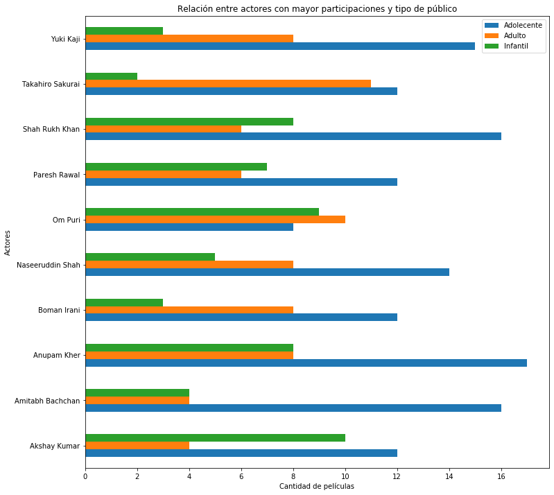

```python
contenido = df.pivot_table(index="actor", columns="publico", aggfunc="count", fill_value=0).plot(kind="barh", legend="Reversed").legend(["Adolecente", "Adulto", "Infantil"])
graficar("Relación entre actores con mayor participaciones y tipo de público", "Cantidad de películas", "Actores")
```

# Pregunta 4: ¿Netflix se ha centrado cada vez más en la televisión en lugar de las películas en los últimos años?

## Relación de contenido de películas y series de TV.

El desglose de tipo de contenido es el siguiente:

```python
copia  = data_origen.copy()
df = copia[["id", "tipo"]]
contenido = df["tipo"].value_counts().to_frame()
contenido.reindex()
contenido["porcentaje"]=round(((contenido["tipo"]/len(data_origen))*100),1)
contenido
```

|  | tipo | porcentaje |
| --- | --- | --- |
| Pelicula | 4265 | 68.4 |
| Serie | 1969 | 31.6 |

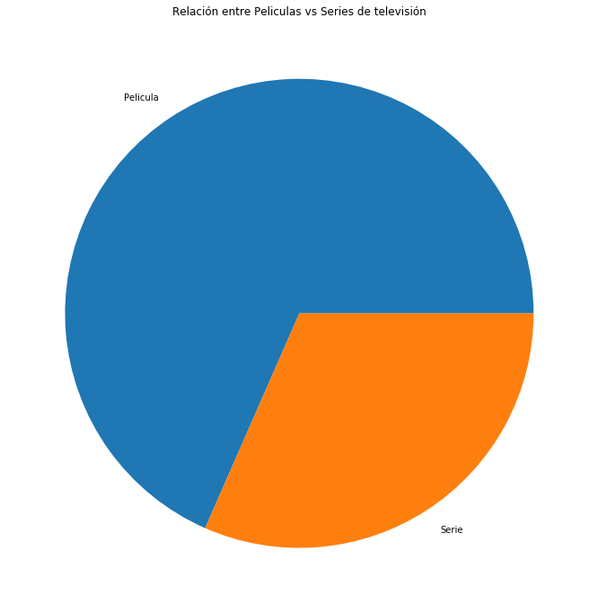

```python
plt.rcParams['figure.figsize'] = (12,12)
data_origen.tipo.groupby(data_origen.tipo).count().plot(kind="pie")
graficar("Relación entre Peliculas vs Series de televisión", "", "")
```

La muestra posee 6234 registros, de los cuales, 4265 (68.4%) corresponden a películas, mientras tanto, 1969 son series de televisión que es un 31.6% de la muestra.

## Relación de contenido de películas y series de TV años 2017-2020

```python
last_years=data_origen.loc[data_origen["lanzamiento"]>=2017, ["lanzamiento", "tipo"]]
contenido = last_years["tipo"].value_counts().to_frame()
contenido.reindex()
contenido["porcentaje"]=round(((contenido["tipo"]/len(last_years))*100),1)
```

Entre los años 2017 y 2020 Netflix ha publicado el siguiente contenido:

```python
contenido
```

|  | tipo | porcentaje |
| --- | --- | --- |
| Pelicula | 1734 | 60.0 |
| Serie | 1156 | 40.0 |

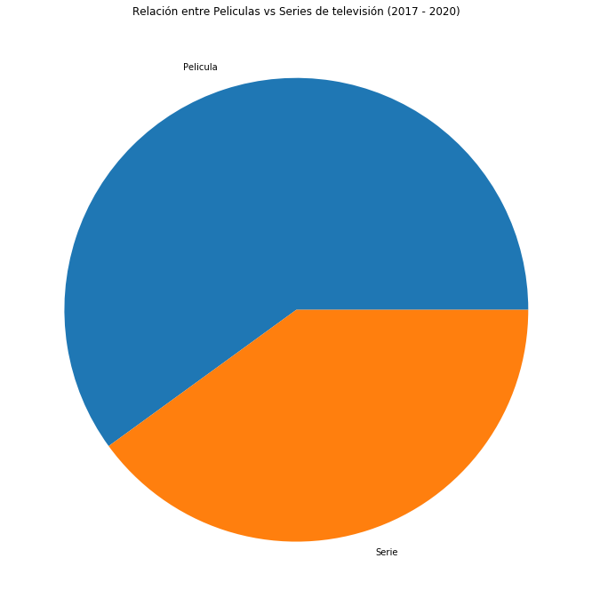

```python
last_years.lanzamiento.groupby(last_years.tipo).count().plot(kind="pie")
graficar("Relación entre Peliculas vs Series de televisión (2017 - 2020)", "", "")
```

Las publicaciones durante el periodo 2017 y 2020 fueron de 2890 elementos, de los cuales el 60% fueron peliculas (1734) y el 40% son series de televisión (1156)

## Relación de contenido de películas y series de TV de los últimos cuatro años (2017-2020)

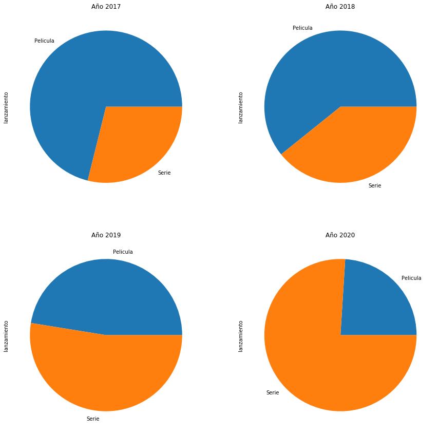

```python
fig=plt.figure(figsize=(15,15))
for i in range(2017,2021):
    ax = plt.subplot(i-1796).set_title("Año "+ str(i).strip())
    df=last_years.loc[last_years["lanzamiento"]==i, ["lanzamiento", "tipo"]]
    df.lanzamiento.groupby(df.tipo).count().plot(kind="pie")
```

```python
%matplotlib inline
plt.show()
```

En los últimos cuatro años, Netflix ha publicado mas películas que series de televisión, en la gráfica se visualiza que en los años 2019 y 2020 el tipo de contenido publicado de series de televisión es superior a las películas, contrastando los resultados de los años 2017 y 2018 en donde las películas poseen la mayoría de publicaciones.